# Testing ITQ Valuations

Ernesto Carrella

August 19, 2015

While ITQ trading is still not enabled, I’d like to test the ability of fishers to evaluate correctly a quota’s worth.  
The main weakness of the ITQ system in the NETLOGO prototype and the Toft’s paper it originates from is that fishers do not accurately discount for “expiration date” of the quotas.

Take a fisher who has to decide whether or not to buy some fishing quotas. If $\Pi_u$ is the profit per unit of fish caught and $\lambda$ is the quota price per unit of fish, then the value of an additional quota is:
$\text{Value of Quota}= \begin{cases} \Pi_u - \lambda,& \text{if quota is used}\\ -\lambda, & \text{otherwise} \end{cases}$ That is, there is the risk of buying a quota and not using it in time which result in the fisher just wasting $\lambda$$.

The expected value of buying a quota (for a risk neutral fisher) is then: $E[\text{Value of Quota}] = \text{Pr}(\text{Needed})(\Pi_u - \lambda) + \text{Pr}(\overline{\text{Needed}})(- \lambda)$ And we can solve for the $\lambda^*$ which is the price that makes fishers indifferent between owning or not a quota $\lambda^* = \text{Pr}(\text{Needed})\Pi_u$

Now if we define: $\begin{align*} q &= \text{Quota owned} \\ c_d &= \text{Daily catch} \\ t &= \text{Day of the season} \\ T &= \text{Season length} \end{align*}$ Then the probability that you are going to use a unit of quota you buy is equal to the probability that: $c_d *(T-t) > q$ That is that catches per day times days left in the season is higher than the number of quotas you have or: $1 - \text{Pr}(c_d \leq \frac{q}{T-t})$ And if we assume that $c_d$ is normally distributed then we are basically saying that $\lambda^* = \left( 1 - \Phi(\frac{q}{T-t}) \right) \Pi_u$

I let fishers use moving averages to predict $c_d$ and $\Pi_u$. We can then ask them what is their estimated $\lambda^*$ as if they currently held $q=1000$ quotas of fish. What follows is the time series of estimated $\lambda^*$ for one fisher in our agent-based model:

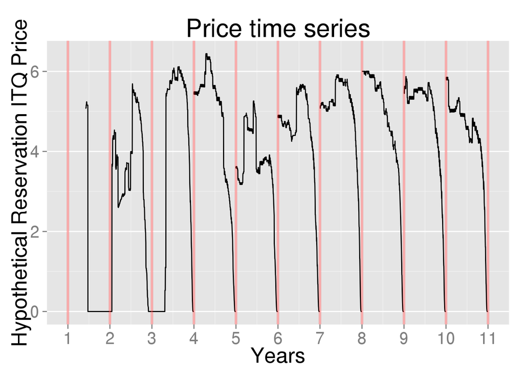

We can also compare the $\lambda$ estimation of different agents. Fishers are all equal in gear and other parameters but their history of exploration and imitation (and luck with social networks) generate heterogeneous results, so that at the 100th day of the 11th year of simulation, the distribution of estimated $\lambda^*$ is as follows:

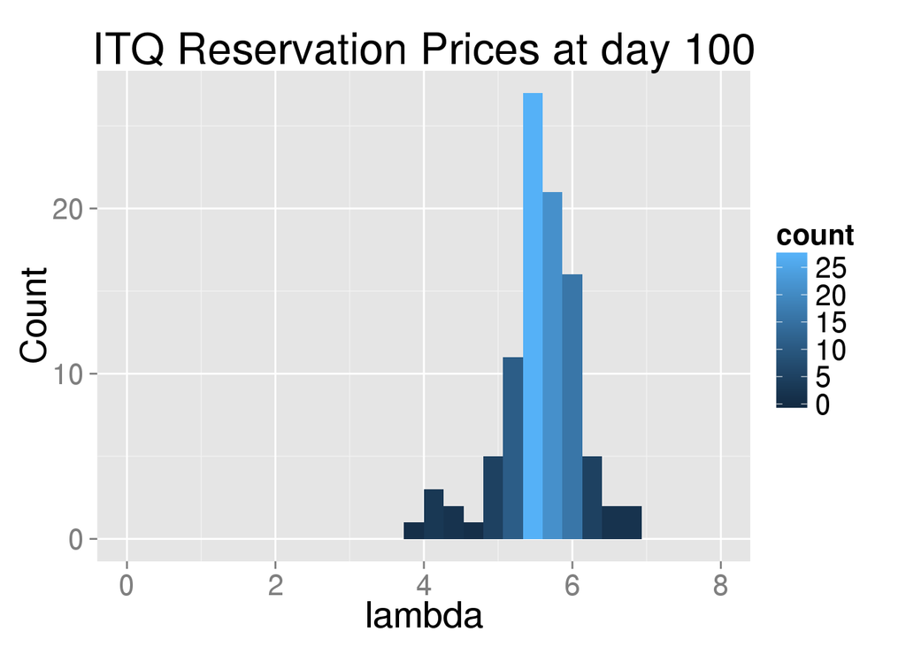

Which would imply plenty of opportunity to trade. Notice also that $\lambda^*$ drops dramatically for everyone towards the end of the year. 5 days before the simulation ends, this is the histogram of predicted $\lambda^*$:

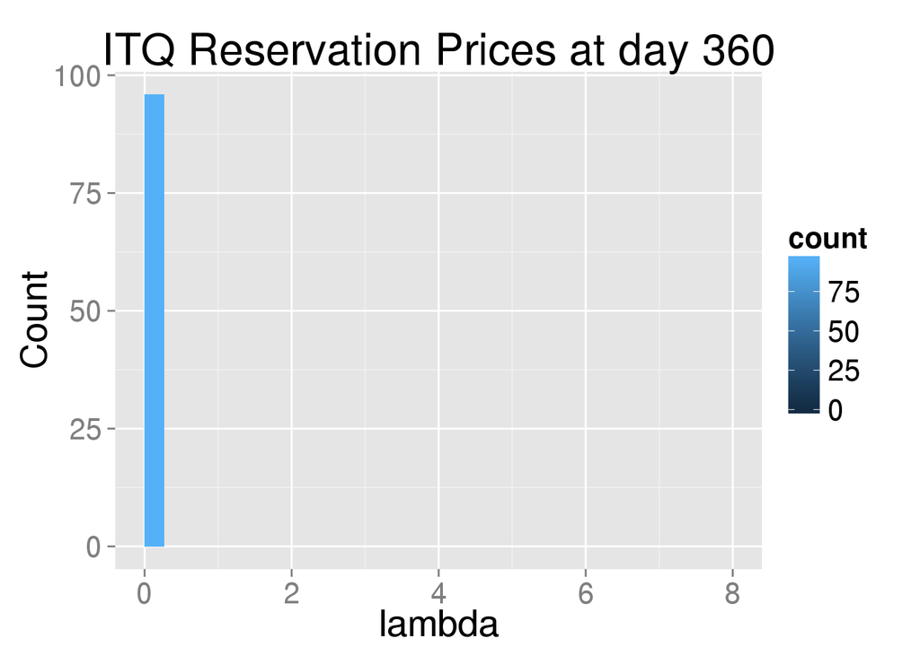